# Excess Abuse Searches During COVID: Analysis and Data Visualization

Krista Neumann

8/17/2021

# Acknowlegment

The code used in this analysis was adapted from a Buzzfeed analysis of excess deaths due to the Texas Winter Storms. Their published R code is available here: https://github.com/BuzzFeedNews/2021-05-tx-winter-storm-deaths

# Data import and cleaning

This code assumes an R project directory with the following sub-folders:

- WeeklyData - containing 3 csv files, one for each of the 3 abuse types. The csv files each contain multiple Google Search samples at the weekly resolution, as pulled via the “01-Pull-Data-From-API.py” file and formatted in wide format
- MonthlyData - containing 3 csv files, one for each of the 3 abuse types. The csv files each contain only 1 Google Search sample at the monthly resolution, as pulled via the “01-Pull-Data-From-API.py”
- ./plots - an empty folder where the data visualizations will be saved

Throughout this analysis we use the following acronyms:

- “CM” - Child abuse victimization (“child abuse”)
- “DV” - Child-witnessed intimate partner violence (“domestic violence”)
- “IPV” - Intimate partner violence victimization (“intimate partner violence”)

## Weekly Data

```r
# Load Weekly data. Single Data file includes all 10 samples for each abuse type.
path <- "/Users/corinneriddell/Box Sync/Google-search-data/Excess Search NATIONAL Analysis/TEST/"

Weekly.CM <- read.csv(paste0(path, "WeeklyData/US-Weekly-CM.csv"),
                      stringsAsFactors = F) %>%
  pivot_longer(cols = c("sample_0":"sample_9"),
               names_to = "SampleNo" , values_to = "value") %>%
  mutate(date = as.Date(period, format = "%Y-%m-%d")) %>%
  group_by(date) %>%
  summarise(mean_value = mean(value)) %>%
  mutate(week_of_year = epiweek(date),
         abuse_type = "CM")


Weekly.DV <- read.csv(paste0(path, "WeeklyData/US-Weekly-DV.csv"), stringsAsFactors = F) %>%
  pivot_longer(cols = c("sample_0":"sample_9"), names_to = "SampleNo" , values_to = "value") %>%
  mutate(date = as.Date(period, format = "%Y-%m-%d")) %>%
  group_by(date) %>%
  summarise(mean_value = mean(value)) %>%
  mutate(week_of_year = epiweek(date),
         abuse_type = "DV")


Weekly.IPV <- read.csv(paste0(path, "WeeklyData/US-Weekly-IPV.csv"), stringsAsFactors = F) %>%
  pivot_longer(cols = c("sample_0":"sample_9"), names_to = "SampleNo" , values_to = "value") %>%
  mutate(date = as.Date(period, format = "%Y-%m-%d")) %>%
  group_by(date) %>%
  summarise(mean_value = mean(value)) %>%
  mutate(week_of_year = epiweek(date),
         abuse_type = "IPV")

Weekly.Data <- rbind(Weekly.CM, Weekly.DV, Weekly.IPV)

# clean up environment
rm(Weekly.CM, Weekly.DV, Weekly.IPV )
```

## Monthly Data

```r
# Load Monthly data. Only a single sample for each abuse type is used for this supplementary analysis.

Monthly.CM <- read.csv(paste0(path, "MonthlyData/US-Monthly-CM.csv"), stringsAsFactors = F)%>%
  mutate(date = as.Date(timestamp, format = "%Y-%m-%d"),
         month_of_year = month(date),
         mean_value = value,
         abuse_type = "CM") %>%
  select(date, mean_value, month_of_year, abuse_type)


Monthly.DV <- read.csv(paste0(path, "MonthlyData/US-Monthly-DV.csv"), stringsAsFactors = F)%>%
  mutate(date = as.Date(timestamp, format = "%Y-%m-%d"),
         month_of_year = month(date),
         mean_value = value,
         abuse_type = "DV") %>%
  select(date, mean_value, month_of_year, abuse_type)


Monthly.IPV <- read.csv(paste0(path, "MonthlyData/US-Monthly-IPV.csv"), stringsAsFactors = F) %>%
  mutate(date = as.Date(timestamp, format = "%Y-%m-%d"),
         month_of_year = month(date),
         mean_value = value,
         abuse_type = "IPV") %>%
  select(date, mean_value, month_of_year, abuse_type)

Monthly.Data <- rbind(Monthly.CM, Monthly.DV, Monthly.IPV)

 # clean up environment
rm(Monthly.CM, Monthly.DV, Monthly.IPV )
```

# Main Analysis: Calculate expected search volume based on pre-pandemic data from 2017-2019

```r
# Data frame to hold observed and expected search volume
Weekly_Excess_Searches <- tibble()
Monthly_Excess_Searches <- tibble()

adj_rsqs <- c(0, 0, 0)
counter <- 0
# Loop over each abuse type to create abuse-specific models and use them to predict expected search volume

for (i in unique(Weekly.Data$abuse_type)) {
  counter <- counter + 1

  Abuse.i.Weekly <- Weekly.Data %>% filter(abuse_type == i)
  Abuse.i.Monthly <- Monthly.Data %>% filter(abuse_type == i)

  # Restrict to pre-2020 data to build models

  Weekly.Data.pre2020 <- Abuse.i.Weekly %>% filter(date < "2020-01-01")
  Monthly.Data.pre2020 <- Abuse.i.Monthly %>% filter(date < "2020-01-01")


  # Fit models

  Weekly.model <- lm(mean_value ~ date + ns(week_of_year,
                                      knots = quantile(week_of_year,
                                            c(0.1, 0.5, 0.9))), data = Weekly.Data.pre2020)

  Monthly.model <- lm(mean_value ~ date + ns(month_of_year,
                                      knots = quantile(month_of_year,
                                            c(0.1, 0.5, 0.9))), data = Monthly.Data.pre2020)

  # Store the adjusted r-squared value
  adj_rsqs[counter] <- broom::glance(Weekly.model) %>% pull(adj.r.squared)

  # Predicted expected search volume based on model for ENTIRE time period
  Weekly_pred <- as_tibble(predict(Weekly.model, Abuse.i.Weekly, interval = "prediction"))
  Monthly_pred <- as_tibble(predict(Monthly.model, Abuse.i.Monthly, interval = "prediction"))


  # Add predictions to dataframe and then add to master Excess Search file
  Abuse.i.Weekly <- bind_cols(Abuse.i.Weekly, Weekly_pred)
  Weekly_Excess_Searches <- bind_rows(Weekly_Excess_Searches, Abuse.i.Weekly)

  Abuse.i.Monthly <- bind_cols(Abuse.i.Monthly, Monthly_pred)
  Monthly_Excess_Searches <- bind_rows(Monthly_Excess_Searches, Abuse.i.Monthly)

}

# Add an indicator for whether the year is 2020

Weekly_Excess_Searches <- Weekly_Excess_Searches %>%
  mutate(after_2020 = as.factor(case_when(date >= as.Date("2020-01-01") ~ 1,
                               date < as.Date("2020-01-01") ~ 0)))

Monthly_Excess_Searches <- Monthly_Excess_Searches %>%
  mutate(after_2020 = as.factor(case_when(date >= as.Date("2020-01-01") ~ 1,
                               date < as.Date("2020-01-01") ~ 0)))

# clean up environment
rm(Abuse.i.Weekly, Abuse.i.Monthly, Weekly.Data.pre2020, Monthly.Data.pre2020,
     Weekly.model, Monthly.model, Weekly_pred, Monthly_pred)
```

# Data Visualizations

We save both the individual ./plots for each abuse type as well as the single combined figure. Output includes:

- ./plots of the weekly data
- ./plots of the monthly data
- ./plots of the weekly and monthly predicted trends together

## Weekly ./plots

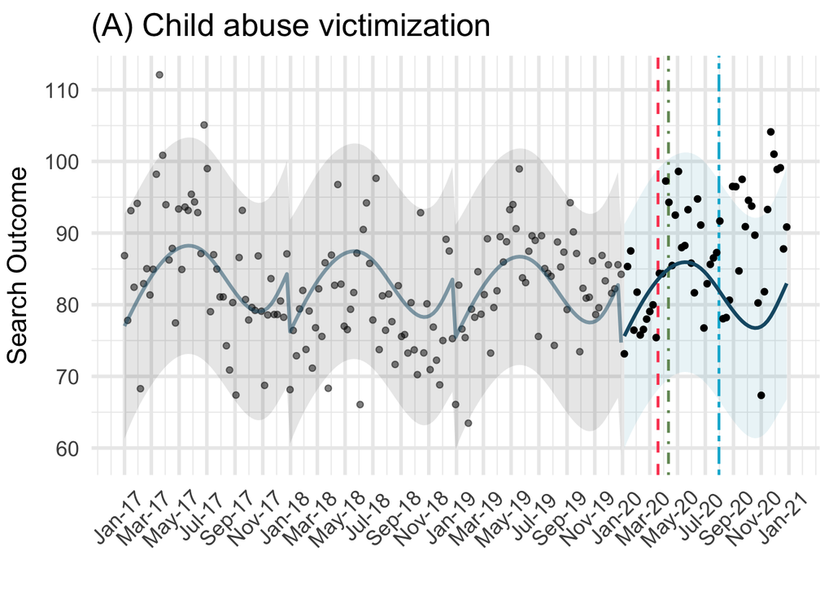

```r
# Set date labels for ./plots
date.vec = seq(from = as.Date("2017-01-01"),
               to = as.Date("2021-01-01"),
               by = "2 months")


# Child abuse victimization ----------------------------------------------------------------------------------------------

CM.Weekly.plot <- ggplot(Weekly_Excess_Searches %>% filter(abuse_type == "CM"),
                         aes(y = mean_value, x = date)) +
  geom_ribbon(data = Weekly_Excess_Searches %>% filter(abuse_type == "CM"),
              aes(ymin = lwr, ymax = upr, fill = after_2020), alpha = 0.1) +
  scale_fill_manual(values=c("black", "#189AB4")) +
  geom_vline(xintercept = as.Date("2020-03-19"), linetype = "dashed", color = "#FB475E", size = .8) +
  geom_vline(xintercept = as.Date("2020-04-11"), linetype = "dotdash", color = "#729663", size = .8) +
  geom_vline(xintercept = as.Date("2020-07-31"), linetype = "twodash", color = "#00B4D4", size = .8) +
  geom_point(aes(alpha = after_2020)) +
  scale_alpha_manual(values=c(0.5, 1)) +
  geom_line(aes(y = fit, x = date, alpha = after_2020), size = 1.05, color = '#175873') +
  theme_minimal(base_size = 16) +
  xlab("") + ylab("Search Outcome") +
  labs(title = "(A) Child abuse victimization") +
  theme(legend.position = "none",
        axis.text.x = element_text(angle = 45, hjust = .7, vjust = .7),
        axis.title.y = element_text(vjust=2),
        panel.grid.minor = element_line(size = 0.3),
        panel.grid.major = element_line(size = 1)) +
  scale_x_date(breaks = date.vec, date_labels = "%b-%y")

CM.Weekly.plot
```

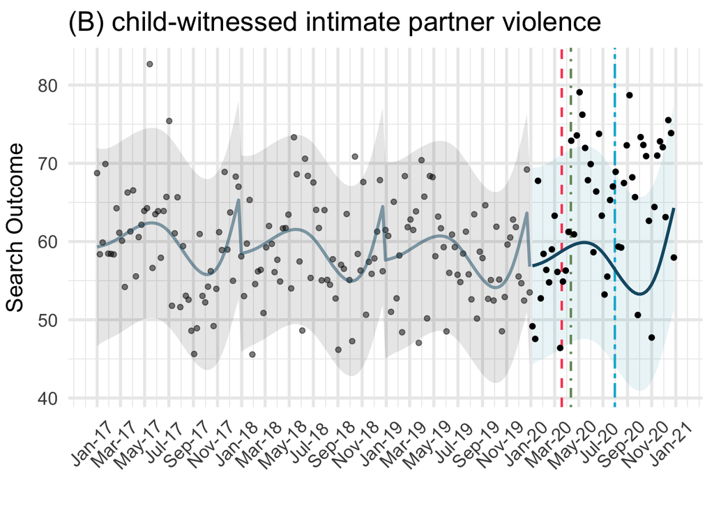

```r
ggsave("./plots/Weekly_Trends_CM.png", CM.Weekly.plot, height = 7, width = 12, units = "in")



# Child-witnessed IPV ----------------------------------------------------------------------------------------------

DV.Weekly.plot <- ggplot(Weekly_Excess_Searches %>% filter(abuse_type == "DV"),
                         aes(y = mean_value, x = date)) +
  geom_ribbon(data = Weekly_Excess_Searches %>% filter(abuse_type == "DV"),
                           aes(ymin = lwr, ymax = upr, fill = after_2020), alpha = 0.1) +
  scale_fill_manual(values=c("black", "#189AB4")) +
  geom_vline(xintercept = as.Date("2020-03-19"), linetype = "dashed", color = "#FB475E", size = .8) +
  geom_vline(xintercept = as.Date("2020-04-11"), linetype = "dotdash", color = "#729663", size = .8) +
  geom_vline(xintercept = as.Date("2020-07-31"), linetype = "twodash", color = "#00B4D4", size = .8) +
  geom_point(aes(alpha = after_2020)) +
  scale_alpha_manual(values=c(0.5, 1)) +
  geom_line(aes(y = fit, x = date, alpha = after_2020), size = 1.05, color = '#175873') +
  theme_minimal(base_size = 16) +
  xlab("") + ylab("Search Outcome") +
  labs(title = "(B) child-witnessed intimate partner violence") +
  theme(legend.position = "none",
        axis.text.x = element_text(angle = 45, hjust = .7, vjust = .7),
        axis.title.y = element_text(vjust=2),
        panel.grid.minor = element_line(size = 0.3),
        panel.grid.major = element_line(size = 1)) +
  scale_x_date(breaks = date.vec, date_labels = "%b-%y")

DV.Weekly.plot
```

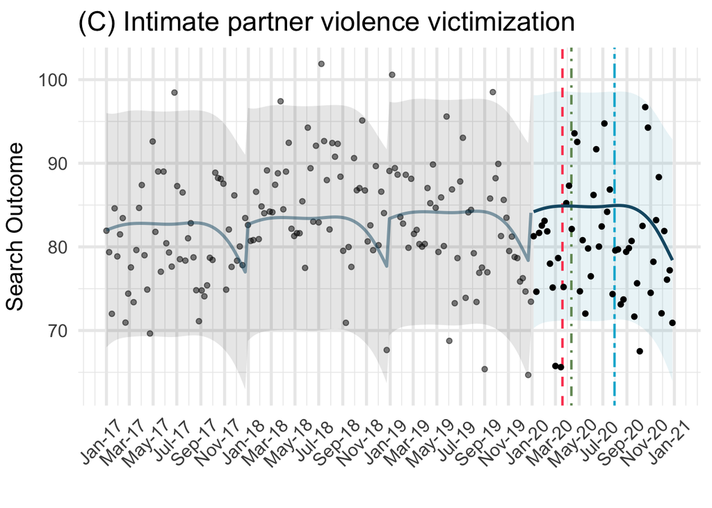

```r
ggsave("./plots/Weekly_Trends_DV.png", DV.Weekly.plot, height = 7, width = 12, units = "in")



# Intimate partner violence victimization  ------------------------------------------------------------------------

IPV.Weekly.plot <- ggplot(Weekly_Excess_Searches %>% filter(abuse_type == "IPV"),
                          aes(y = mean_value, x = date)) +
  geom_ribbon(data = Weekly_Excess_Searches %>% filter(abuse_type == "IPV"),
              aes(ymin = lwr, ymax = upr, fill = after_2020), alpha = 0.1) +
  scale_fill_manual(values=c("black", "#189AB4")) +
  geom_vline(xintercept = as.Date("2020-03-19"), linetype = "dashed", color = "#FB475E", size = .8) +
  geom_vline(xintercept = as.Date("2020-04-11"), linetype = "dotdash", color = "#729663", size = .8) +
  geom_vline(xintercept = as.Date("2020-07-31"), linetype = "twodash", color = "#00B4D4", size = .8) +
  geom_point(aes(alpha = after_2020)) +
  scale_alpha_manual(values=c(0.5, 1)) +
  geom_line(aes(y = fit, x = date, alpha = after_2020), size = 1.05, color = '#175873') +
  theme_minimal(base_size = 16) +
  xlab("") + ylab("Search Outcome") +
  labs(title = "(C) Intimate partner violence victimization") +
  theme(legend.position = "none",
        axis.text.x = element_text(angle = 45, hjust = .7, vjust = .7), #vjust = .5
        axis.title.y = element_text(vjust=2),
        panel.grid.minor = element_line(size = 0.3),
        panel.grid.major = element_line(size = 1)) +
  scale_x_date(breaks = date.vec, date_labels = "%b-%y")

IPV.Weekly.plot
```

```r
ggsave("./plots/Weekly_Trends_IPV.png", IPV.Weekly.plot, height = 7, width = 12, units = "in")



# Combined Plot ----------------------------------------------------------------------------------------------

Weekly.Combined.plot <- CM.Weekly.plot/DV.Weekly.plot/IPV.Weekly.plot
ggsave("./plots/Weekly_Trends_Combined.png", Weekly.Combined.plot, height = 18, width = 16, units = "in", dpi = 150)
```

## Monthly ./plots

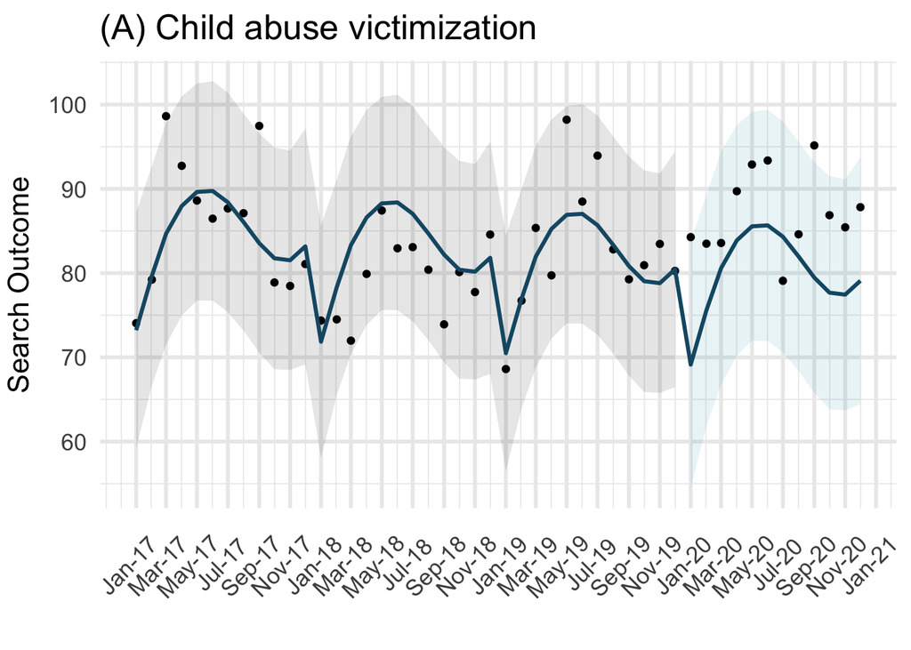

```r
# Set date labels for ./plots
date.vec = seq(from = as.Date("2017-01-01"),
               to = as.Date("2021-01-01"),
               by = "2 months")


# Child abuse victimization ----------------------------------------------------------------------------------------------

CM.Monthly.plot <- ggplot(Monthly_Excess_Searches %>% filter(abuse_type == "CM"),
                          aes(y = mean_value, x = date)) +
  geom_ribbon(data = Monthly_Excess_Searches %>% filter(abuse_type == "CM"),
              aes(ymin = lwr, ymax = upr, fill = after_2020), alpha = 0.1) +
  scale_fill_manual(values=c("black", "#189AB4")) +
  geom_point() +
  geom_line(aes(y = fit, x = date), size = 1.05, color = '#175873') +
  theme_minimal(base_size = 16) +
  xlab("") + ylab("Search Outcome") +
  labs(title = "(A) Child abuse victimization") +
  theme(legend.position = "none",
        axis.text.x = element_text(angle = 45, hjust = .7, vjust = .7),
        axis.title.y = element_text(vjust=2),
        axis.ticks.length.x = unit(10, "pt"),
        panel.grid.minor = element_line(size = 0.3),
        panel.grid.major = element_line(size = 1)) +
  scale_x_date(breaks = date.vec,
               date_labels = "%b-%y")

CM.Monthly.plot
```

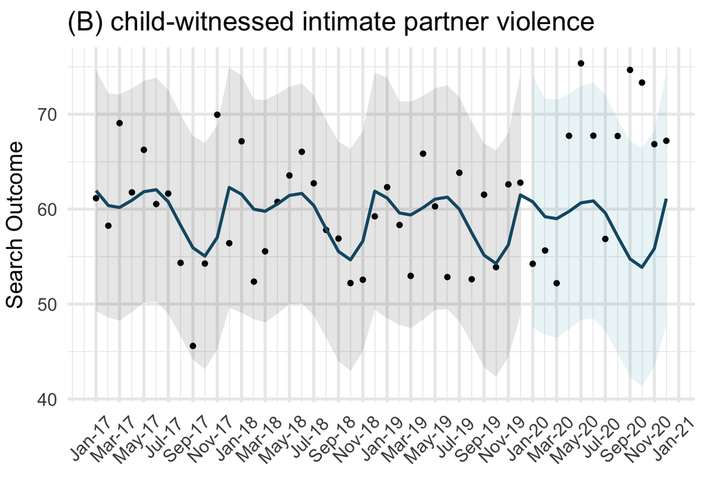

```r
ggsave("./plots/Monthly_Trends_CM.png", CM.Monthly.plot, height = 7, width = 12, units = "in")



# Child-witnessed IPV ----------------------------------------------------------------------------------------------

DV.Monthly.plot <- ggplot(Monthly_Excess_Searches %>% filter(abuse_type == "DV"),
                          aes(y = mean_value, x = date)) +
  geom_ribbon(data = Monthly_Excess_Searches %>% filter(abuse_type == "DV"),
              aes(ymin = lwr, ymax = upr, fill = after_2020), alpha = 0.1) +
  scale_fill_manual(values=c("black", "#189AB4")) +
  geom_point() +
  geom_line(aes(y = fit, x = date), size = 1.05, color = '#175873') +
  theme_minimal(base_size = 16) +
  xlab("") + ylab("Search Outcome") +
  labs(title = "(B) child-witnessed intimate partner violence") +
  theme(legend.position = "none",
        axis.text.x = element_text(angle = 45, hjust = .7, vjust = .7),
        axis.title.y = element_text(vjust=2),
        panel.grid.minor = element_line(size = 0.3),
        panel.grid.major = element_line(size = 1)) +
  scale_x_date(breaks = date.vec,
               date_labels = "%b-%y")

DV.Monthly.plot
```

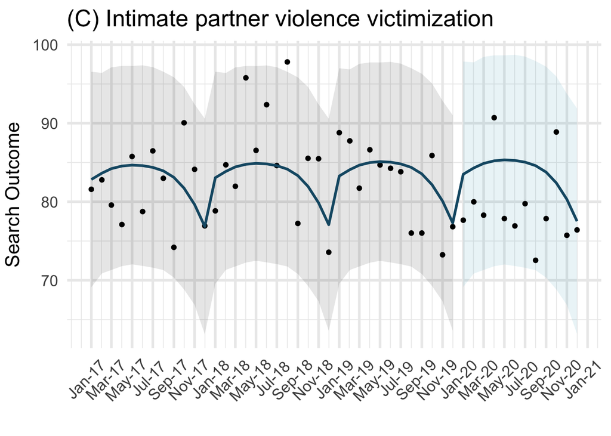

```r
ggsave("./plots/Monthly_Trends_DV.png", DV.Monthly.plot, height = 7, width = 12, units = "in")



# Intimate partner violence victimization ----------------------------------------------------------------------------

IPV.Monthly.plot <- ggplot(Monthly_Excess_Searches %>% filter(abuse_type == "IPV"),
                           aes(y = mean_value, x = date)) +
  geom_ribbon(data = Monthly_Excess_Searches %>% filter(abuse_type == "IPV"),
              aes(ymin = lwr, ymax = upr, fill = after_2020), alpha = 0.1) +
  scale_fill_manual(values=c("black", "#189AB4")) +
  geom_point() +
  geom_line(aes(y = fit, x = date), size = 1.05, color = '#175873') +
  theme_minimal(base_size = 16) +
  xlab("") + ylab("Search Outcome") +
  labs(title = "(C) Intimate partner violence victimization") +
  theme(legend.position = "none",
        axis.text.x = element_text(angle = 45, hjust = .7, vjust = .7), #vjust = .5
        axis.title.y = element_text(vjust=2),
        panel.grid.minor = element_line(size = 0.3),
        panel.grid.major = element_line(size = 1)) +
  scale_x_date(breaks = date.vec,
               date_labels = "%b-%y")

IPV.Monthly.plot
```

```r
ggsave("./plots/Monthly_Trends_DV.png", IPV.Monthly.plot, height = 7, width = 12, units = "in")



# Combined Plot ----------------------------------------------------------------------------------------------

Monthly.Combined.plot <- CM.Monthly.plot/DV.Monthly.plot/IPV.Monthly.plot
ggsave("./plots/Monthly_Trends_Combined.png", Monthly.Combined.plot, height = 18, width = 16, units = "in", dpi = 150)
```

## Weekly and Monthly predicted trends together on one plot

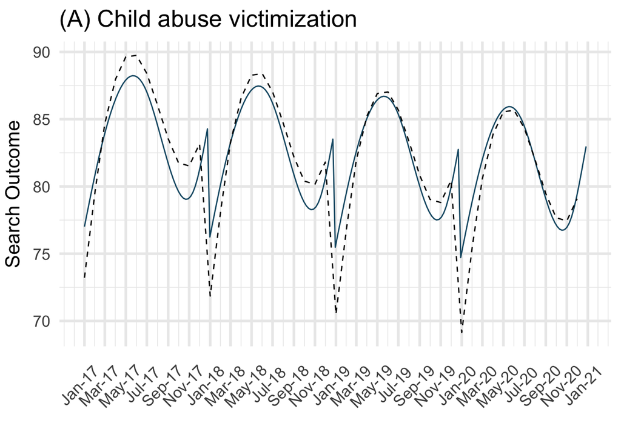

```r
# Set date labels for plot
date.vec = seq(from = as.Date("2017-01-01"),
               to = as.Date("2021-01-01"),
               by = "2 months")


# Child abuse victimization ----------------------------------------------------------------------------------------------

CM.Together.plot <- ggplot(Weekly_Excess_Searches %>% filter(abuse_type == "CM"),
                           aes(y = fit, x = date)) +
  geom_line(color = '#175873') +
  geom_line(data = Monthly_Excess_Searches %>% filter(abuse_type == "CM"),
            linetype = "dashed", color = "black" ) +
  theme_minimal(base_size = 16) +
  xlab("") + ylab("Search Outcome") +
  labs(title = "(A) Child abuse victimization") +
  theme(legend.position = "none",
        axis.text.x = element_text(angle = 45, hjust = .7, vjust = .7),
        axis.title.y = element_text(vjust=2),
        axis.ticks.length.x = unit(10, "pt"),
        panel.grid.minor = element_line(size = 0.3),
        panel.grid.major = element_line(size = 1)) +
  scale_x_date(breaks = date.vec, date_labels = "%b-%y")

CM.Together.plot
```

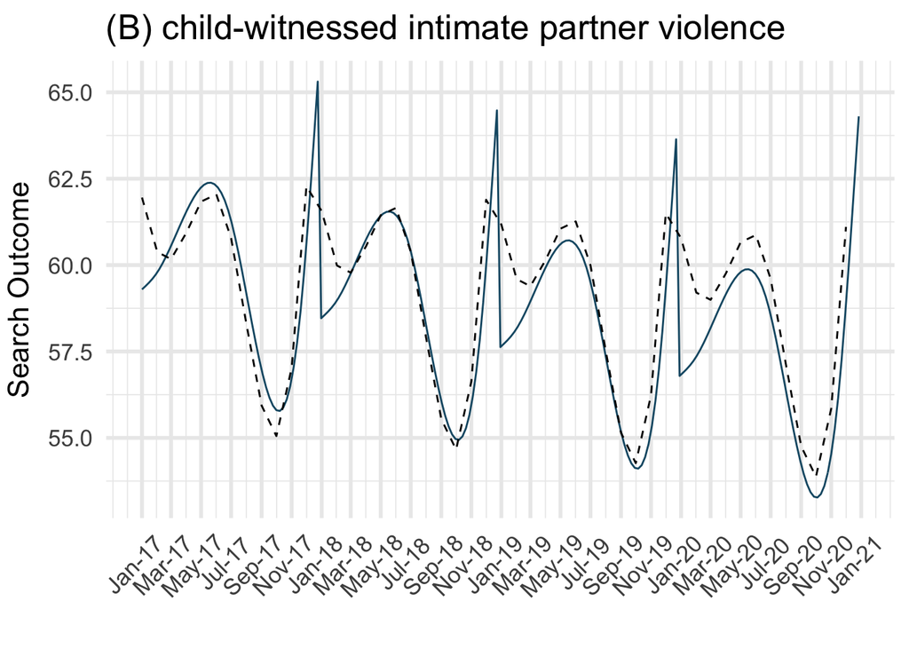

```r
ggsave("./plots/Both_Trends_CM.png", CM.Together.plot, height = 7, width = 12, units = "in")



# Child-witnessed IPV ----------------------------------------------------------------------------------------------

DV.Together.plot <- ggplot(Weekly_Excess_Searches %>% filter(abuse_type == "DV"),
                           aes(y = fit, x = date)) +
  geom_line(color = '#175873') +
  geom_line(data = Monthly_Excess_Searches %>% filter(abuse_type == "DV"),
            linetype = "dashed", color = "black" ) +
  theme_minimal(base_size = 16) +
  xlab("") + ylab("Search Outcome") +
  labs(title = "(B) child-witnessed intimate partner violence") +
  theme(legend.position = "none",
        axis.text.x = element_text(angle = 45, hjust = .7, vjust = .7),
        axis.title.y = element_text(vjust=2),
        panel.grid.minor = element_line(size = 0.3),
        panel.grid.major = element_line(size = 1)) +
  scale_x_date(breaks = date.vec, date_labels = "%b-%y")

DV.Together.plot
```

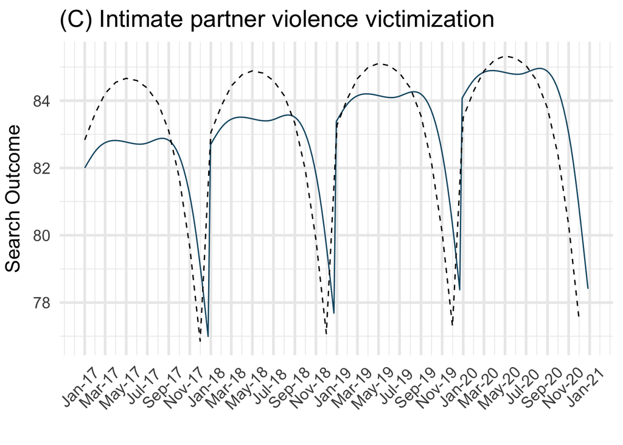

```r
ggsave("./plots/Both_Trends_DV.png", DV.Together.plot, height = 7, width = 12, units = "in")



# Intimate partner violence victimization -------------------------------------------------------------------------------

IPV.Together.plot <- ggplot(Weekly_Excess_Searches %>% filter(abuse_type == "IPV"),
                            aes(y = fit, x = date)) +
  geom_line(color = '#175873') +
  geom_line(data = Monthly_Excess_Searches %>% filter(abuse_type == "IPV"),
            linetype = "dashed", color = "black" ) +
  theme_minimal(base_size = 16) +
  xlab("") + ylab("Search Outcome") +
  labs(title = "(C) Intimate partner violence victimization") +
  theme(legend.position = "none",
        axis.text.x = element_text(angle = 45, hjust = .7, vjust = .7), #vjust = .5
        axis.title.y = element_text(vjust=2),
        panel.grid.minor = element_line(size = 0.3),
        panel.grid.major = element_line(size = 1)) +
  scale_x_date(breaks = date.vec, date_labels = "%b-%y")

IPV.Together.plot
```

```r
ggsave("./plots/Both_Trends_IPV.png", IPV.Together.plot, height = 7, width = 12, units = "in")



# Combined Plot ----------------------------------------------------------------------------------------------

Plot.Combined.Trends <- CM.Together.plot/DV.Together.plot/IPV.Together.plot
ggsave("./plots/Both_Trends_Combined.png", Plot.Combined.Trends, height = 18, width = 16, units = "in", dpi = 150)
```